# 1. Working with Vector Data using Geopandas

In this section, we will explore how to work with vector data using Geopandas, a powerful Python library that extends the capabilities of pandas to allow for easy handling of geospatial data.

## Introduction to Geopandas

**Geopandas** is an open-source project that simplifies the process of working with geospatial data in Python. It extends the datatypes used by pandas to allow spatial operations on geometric types. Geometric operations are performed by shapely, while Geopandas also depends on Fiona for file access and matplotlib for plotting.

### Key Features:

- **Integration with Pandas:** Geopandas provides a high-level interface to manipulate data in a way similar to pandas.
- **Support for Different Geospatial File Formats:** Including Shapefile, GeoJSON, KML, and others.
- **Spatial Operations:** Such as union, intersection, and spatial joins.

## Data Structures in Geopandas

### 1. GeoSeries:

- A **GeoSeries** is essentially a series of geometric objects, such as points, lines, and polygons.
- Each entry in a GeoSeries is a set of shape coordinates representing a geometric shape.

### 2. GeoDataFrame:

- A **GeoDataFrame** extends the functionalities of pandas' DataFrame with a special column, typically named 'geometry', that contains the geometric information.
- It can contain other columns with attributes describing each of the geometries.

## Reading and Writing Spatial Data

### Reading Data:

- Geopandas can read any data format recognized by Fiona. The most common method of reading spatial data is using the `geopandas.read_file()` function.
- **Example:**

  ```
  import geopandas as gpd
  gdf = gpd.read_file("path_to_shapefile.shp")
  ```

### Writing Data:

- You can also export your GeoDataFrame to various formats using the `to_file()` method.
- **Example:**

  ```
  gdf.to_file("output_path.shp")
  ```

## Practical Application

In practice, working with vector data in Geopandas allows analysts to perform complex spatial analyses and visualizations. Common applications include mapping, spatial querying, and conducting spatial joins between datasets.

## Citations and Sources

- Joris Van den Bossche, et al. "Geopandas: Geographic pandas extensions." (2019). [Geopandas Documentation](https://geopandas.org/en/stable/)
  - The official Geopandas documentation provides comprehensive guidance on all functionalities of the library.
- McKinney, Wes. "Data Structures for Statistical Computing in Python." Proceedings of the 9th Python in Science Conference. Vol. 445. 2010.
  - This paper discusses the pandas library, which forms the foundation for Geopandas.
- Hug, Sean Gillies, and Others. Fiona: Read and Write Geographic Data Files. 2018.
  - Fiona is used by Geopandas for file access, and its documentation offers insights into data handling.

```python
import geopandas as gpd
gdf = gpd.read_file("../01_Data_IO/data_sample/sample_shp.shp")
```

```python
gdf.to_file("output_path.shp")
```

# 2. Spatial Joins and Overlays

Spatial joins and overlays are essential operations in geospatial analysis, allowing for the combination and integration of different spatial datasets based on their geometric relationships.

## Introduction to Spatial Joins

Spatial joins merge two GeoDataFrames based on their spatial relationship. Unlike traditional joins in relational databases, spatial joins use geographic information to align records.

### Types of Spatial Relationships:

- **Intersects:** Where geometries from both datasets share any space.
- **Within:** Where a geometry from one dataset is completely inside a geometry of the other dataset.
- **Contains:** The inverse of "within" – where one geometry encloses another.

### Types of Joins:

- **Inner Join:** Returns records with matching geometries in both datasets.
- **Left Join:** Returns all records from the left dataset and matched records from the right dataset.
- **Right Join:** Returns all records from the right dataset and matched records from the left dataset.
- **Outer Join:** Returns all records when there is a match in either left or right dataset.

## Introduction to Spatial Overlays

Spatial overlays allow for the combination of two GeoDataFrames to create a new set of geometries and merge their associated data based on spatial relationships.

### Types of Overlay Operations:

- **Union:** Combines all geometries from both datasets.
- **Intersection:** Returns geometries that are common to both datasets.
- **Difference:** Subtracts geometries of the second dataset from the first.

## Practical Application in Geopandas

Geopandas makes these operations straightforward. Here's how these concepts are applied:

### Spatial Joins:

```
import geopandas as gpd

# Load datasets
gdf1 = gpd.read_file("dataset1.shp")
gdf2 = gpd.read_file("dataset2.shp")

# Perform a spatial join
joined_gdf = gpd.sjoin(gdf1, gdf2, how="inner", predicate="intersects")
```

### Spatial Overlays:

```
# Perform an overlay operation
overlay_gdf = gpd.overlay(gdf1, gdf2, how="intersection")
```

## Citations and Sources

- Anselin, L. (1995). "Local Indicators of Spatial Association—LISA." Geographical Analysis.
  - Discusses spatial relationships and their importance in geospatial analysis.
- O'Sullivan, D., & Unwin, D. J. (2010). Geographic Information Analysis. John Wiley & Sons.
  - This book provides a comprehensive overview of geographic information analysis, including spatial joins and overlays.
- Geopandas Documentation: https://geopandas.org/en/stable/
  - The official Geopandas documentation, a key resource for understanding how to implement spatial joins and overlays in Python.

```python
import geopandas as gpd
from shapely.geometry import Point, Polygon

# Create a simple set of point geometries
points = [Point(1, 1), Point(2, 2), Point(3, 3)]
point_gdf = gpd.GeoDataFrame(geometry=points)
point_gdf['id'] = [1, 2, 3]  # Adding an id column

# Create a simple set of polygon geometries
polygons = [Polygon([(0, 0), (2, 0), (2, 2), (0, 2)]), Polygon([(1, 1), (3, 1), (3, 3), (1, 3)])]
polygon_gdf = gpd.GeoDataFrame(geometry=polygons)
polygon_gdf['region'] = ['A', 'B']  # Adding a region column

# Save the GeoDataFrames as shapefiles
point_gdf.to_file("simple_points.shp")
polygon_gdf.to_file("simple_polygons.shp")
```

```python
import geopandas as gpd
from shapely.geometry import Point

# Load the shapefiles
points_gdf = gpd.read_file("simple_points.shp")
polygons_gdf = gpd.read_file("simple_polygons.shp")
```

```python
# Spatial join - points within polygons
joined_gdf = gpd.sjoin(points_gdf, polygons_gdf, how="inner", predicate="within")
print("Spatial Join (Points within Polygons):\n", joined_gdf)
```

```
Spatial Join (Points within Polygons):
    id                 geometry  index_right region
0   1  POINT (1.00000 1.00000)            0      A
1   2  POINT (2.00000 2.00000)            1      B
```

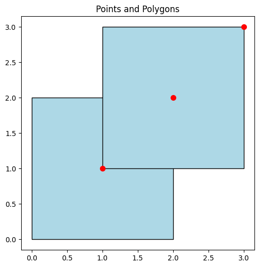

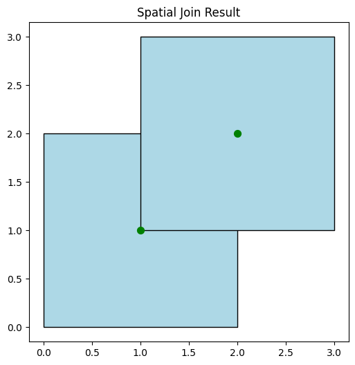

```python
import matplotlib.pyplot as plt

# Plotting points and polygons
fig, ax = plt.subplots(figsize=(6, 6))
polygons_gdf.plot(ax=ax, color='lightblue', edgecolor='black')
points_gdf.plot(ax=ax, color='red', markersize=50)
plt.title('Points and Polygons')
plt.show()

# Spatial join - points within polygons
joined_gdf = gpd.sjoin(points_gdf, polygons_gdf, how="inner", predicate="within")

# Plotting the spatial join result
fig, ax = plt.subplots(figsize=(6, 6))
polygons_gdf.plot(ax=ax, color='lightblue', edgecolor='black')
joined_gdf.plot(ax=ax, color='green', markersize=50)
plt.title('Spatial Join Result')
plt.show()
```

```python
# Overlay - intersection of polygons
overlay_gdf = gpd.overlay(points_gdf, polygons_gdf, how="intersection")
print("Overlay (Intersection of Points and Polygons):\n", overlay_gdf)
```

```
Overlay (Intersection of Points and Polygons):
    id region                 geometry
0   1      A  POINT (1.00000 1.00000)
1   2      A  POINT (2.00000 2.00000)
2   1      B  POINT (1.00000 1.00000)
3   2      B  POINT (2.00000 2.00000)
4   3      B  POINT (3.00000 3.00000)
```

```python
# Plotting the overlay result
fig, ax = plt.subplots(figsize=(6, 6))
overlay_gdf.plot(ax=ax, color='purple', markersize=50)
plt.title('Overlay Result (Intersection)')
plt.show()
```

[output not shown]

# 3. Basic Spatial Statistics

Spatial statistics involves the analysis and interpretation of spatial data. It focuses on the spatial arrangement of features and their properties, including aspects like location, distance, area, and spatial relationships.

## Introduction to Spatial Statistics

Spatial statistics is a branch of statistics that deals with the analysis of spatial and spatiotemporal data. It is critical in geoscience, environmental science, public health, urban planning, and other fields where understanding spatial patterns and relationships is essential.

### Key Concepts:

- **Spatial Autocorrelation:** Measures how much a spatial feature is similar to nearby features. High spatial autocorrelation indicates that features close to each other are more likely to have similar values.
- **Spatial Interpolation:** Estimating values at unsampled locations within the area covered by existing observations.

## Measuring Distance and Area

### Distance Calculation:

- **Euclidean Distance:** The straight-line distance between two points. Most common but does not account for curvature of the Earth.
- **Geodesic Distance:** Measures the shortest distance on the Earth's surface, more accurate for large distances.

### Area Calculation:

- Area calculations in spatial datasets depend on the coordinate reference system. Projected coordinate systems provide more accurate area calculations than geographic coordinate systems.

## Spatial Aggregation

Spatial aggregation involves grouping spatial data based on specific criteria, often to simplify analysis or visualize complex datasets. Examples include summarizing demographic data within political boundaries or aggregating environmental measurements by land use types.

## Basic Geometric Operations

- **Buffer:** Creates a zone of a specified distance around spatial features. Used for proximity analysis.
- **Centroid:** Calculates the geometric center of a polygon.
- **Convex Hull:** Creates the smallest convex polygon that encloses a set of spatial features.

## Practical Application with Python

Python libraries such as Geopandas and Shapely provide functionalities to perform basic spatial statistics:

### Example Code:

```
import geopandas as gpd

# Load a GeoDataFrame
gdf = gpd.read_file("path_to_data.shp")

# Calculate centroid and area
gdf['centroid'] = gdf.geometry.centroid
gdf['area'] = gdf.geometry.area
```

## Citations and Sources

- Bailey, T. C., & Gatrell, A. C. (1995). Interactive Spatial Data Analysis. Longman Scientific & Technical.
  - Provides an in-depth understanding of spatial data analysis techniques.
- Cressie, N. (1993). Statistics for Spatial Data. Wiley-Interscience.
  - A foundational text covering various aspects of spatial statistics.
- Geopandas Documentation: https://geopandas.org/en/stable/
  - Offers detailed information on performing spatial statistics using Geopandas.

```python
# Distance between first point and all other points
distances = points_gdf.geometry.apply(lambda g: g.distance(Point(1, 1)))
print("Distances from Point (1,1) to all points:\n", distances)
```

```
Distances from Point (1,1) to all points:
 0    0.000000
1    1.414214
2    2.828427
dtype: float64
```

```python
# Calculating areas of polygons
areas = polygons_gdf.area
print("Areas of Polygons:\n", areas)
```

```
Areas of Polygons:
 0    4.0
1    4.0
dtype: float64
```

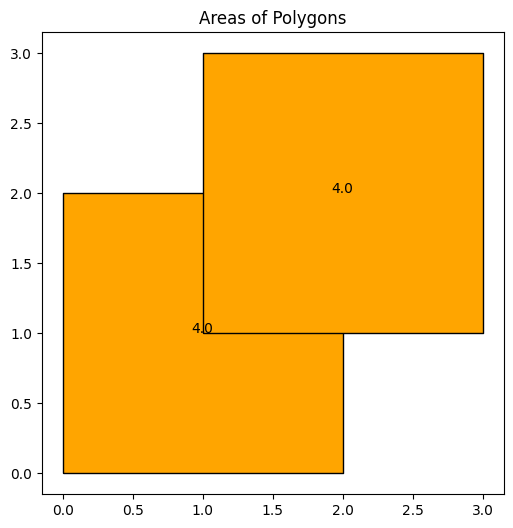

```python
# Plotting areas of polygons
fig, ax = plt.subplots(figsize=(6, 6))
polygons_gdf.plot(ax=ax, color='orange', edgecolor='black')
polygons_gdf.apply(lambda x: ax.annotate(text=round(x.geometry.area, 2), xy=x.geometry.centroid.coords[0], ha='center'), axis=1)
plt.title('Areas of Polygons')
plt.show()
```

```python
# Spatial aggregation - count points in each polygon
aggregation = joined_gdf.groupby('region').size()
print("Count of Points in each Polygon:\n", aggregation)
```

```
Count of Points in each Polygon:
 region
A    1
B    1
dtype: int64
```

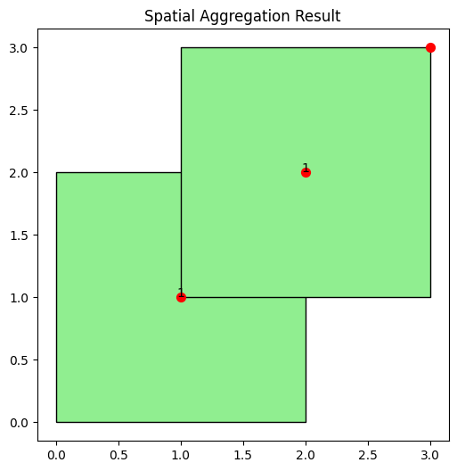

```python
# Spatial aggregation - count points in each polygon
aggregation = joined_gdf.groupby('region').size()

# Plotting the aggregation result
fig, ax = plt.subplots(figsize=(6, 6))
polygons_gdf.plot(ax=ax, color='lightgreen', edgecolor='black')
points_gdf.plot(ax=ax, color='red', markersize=50)
polygons_gdf.apply(lambda x: ax.annotate(text=aggregation.get(x['region'], 0), xy=x.geometry.centroid.coords[0], ha='center'), axis=1)
plt.title('Spatial Aggregation Result')
plt.show()
```

```python
# Buffer operation on points
buffered_points = points_gdf.buffer(0.5)
print("Buffered Points:\n", buffered_points)

# Centroid of polygons
centroids = polygons_gdf.centroid
print("Centroids of Polygons:\n", centroids)
```

```
Buffered Points:
 0    POLYGON ((1.50000 1.00000, 1.49759 0.95099, 1....
1    POLYGON ((2.50000 2.00000, 2.49759 1.95099, 2....
2    POLYGON ((3.50000 3.00000, 3.49759 2.95099, 3....
dtype: geometry
Centroids of Polygons:
 0    POINT (1.00000 1.00000)
1    POINT (2.00000 2.00000)
dtype: geometry
```

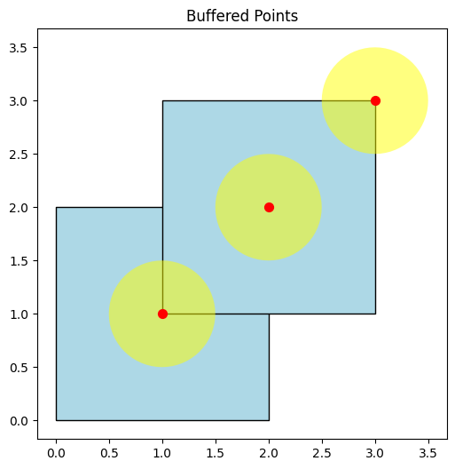

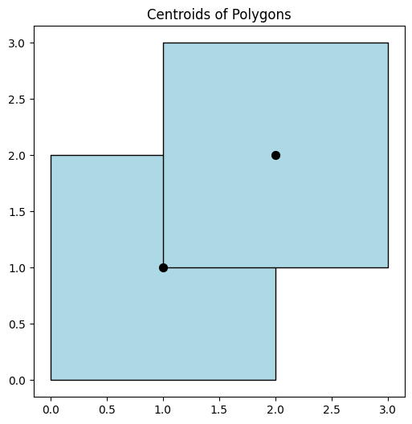

```python
# Plotting buffered points
fig, ax = plt.subplots(figsize=(6, 6))
polygons_gdf.plot(ax=ax, color='lightblue', edgecolor='black')
buffered_points.plot(ax=ax, color='yellow', alpha=0.5)
points_gdf.plot(ax=ax, color='red', markersize=50)
plt.title('Buffered Points')
plt.show()

# Centroid of polygons
# Plotting centroids of polygons
fig, ax = plt.subplots(figsize=(6, 6))
polygons_gdf.plot(ax=ax, color='lightblue', edgecolor='black')
centroids.plot(ax=ax, color='black', markersize=50)
plt.title('Centroids of Polygons')
plt.show()
```